# Rapport AD

HARTLEY Marc - HERVÉ Victor

03/11/2019

# 1 Introduction

Notre jeu de données présente 40 patients. Les 20 premiers sont en bonnes santés alors que les autres sont malades. Les patients sont représentés en colonnes et les gènes en lignes.

Nous savons qu’il existe de nombreuses maladies dues à l’expression des gènes. On dénombre entre 6000 et 8000 maladies génétiques dans le mondes. Leurs causes ainsi que leurs symptômes sont divers en variés. Ces maladies peuvent être héréditaires ou simplement dues à des mutatations génétiques dans la vie adulte. Ainsi la modification d’un gène peut provoquer des protéines déficientes et le fonctionnement anormal de nombreuses cellules. Dans 80% des cas, un maladie génétique serait due à l’altération d’une séquence codante d’un gène. Le but de notre études est de trouver les gènes ou les groupes responsables des maladies sur nos patients par une analyse en composante principale (ACP ou PCA en anglais).

# 2 Description des individus

Sur nos quarante individus, nous remarquons que chaque individu a des gènes qui s’expriments plus que d’autres et d’autres qui s’expriment moins bien. Sur le graphique nos pouvons voir que ces gênes sont mis en avant par leurs valeurs atypiques qui se retrouvent aux extrémités des boîtes à moustache.

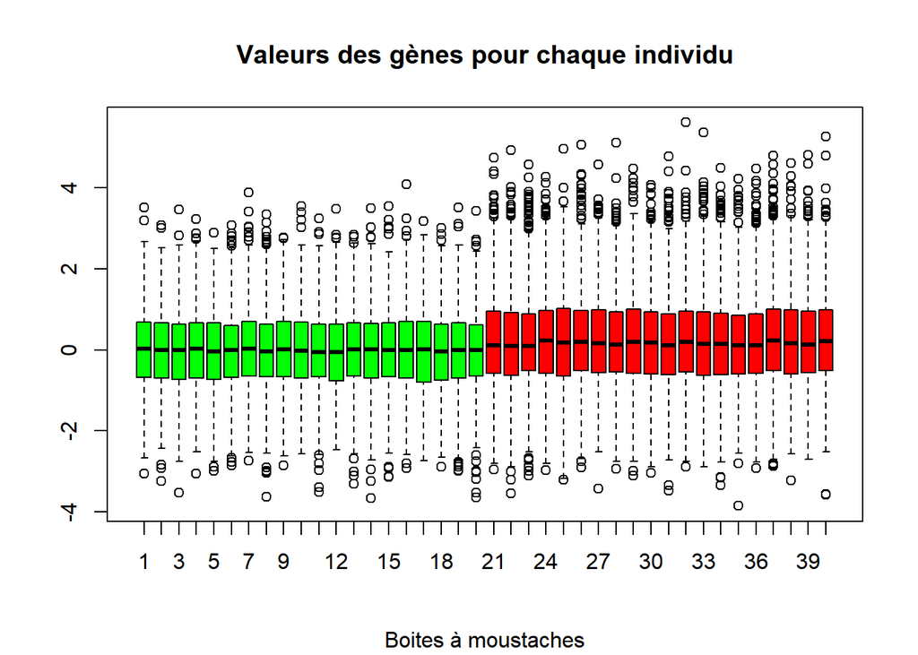

Cependant, l’expression des gènes chez les individus sains diffèrent de leurs expressions par rapport aux individus qui sont malades :

[figure not shown]

En effet nous pouvous remarquer que nous avons quasiment autant de gênes qui sont sur-exprimés et sous exprimés chez les individus sains. Alors que pour les individus malades nous avons beaucoups plus de gènes qui sont sur-exprimés comme le montre le graphique ci-dessous.

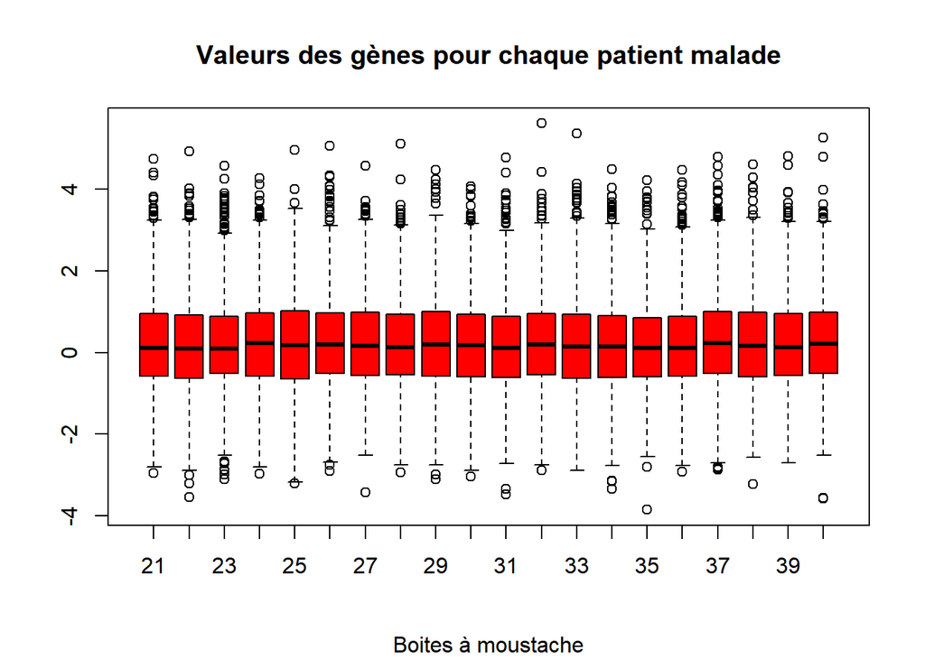

C’est pour cela que les boites à moustaches des individus malades ont une médiane tirée vers le haut par rapport aux individus sains.

Nous pouvons premièrement conjecturer que les deux groupes d’individus sont alors différenciés par certains gènes. Nous allons essayer de décrire ces gènes par la suite.

# 3 Description des gènes

Ici nous pouvons remarquer que la distribution de l’expression est étendue de -4 à 4.

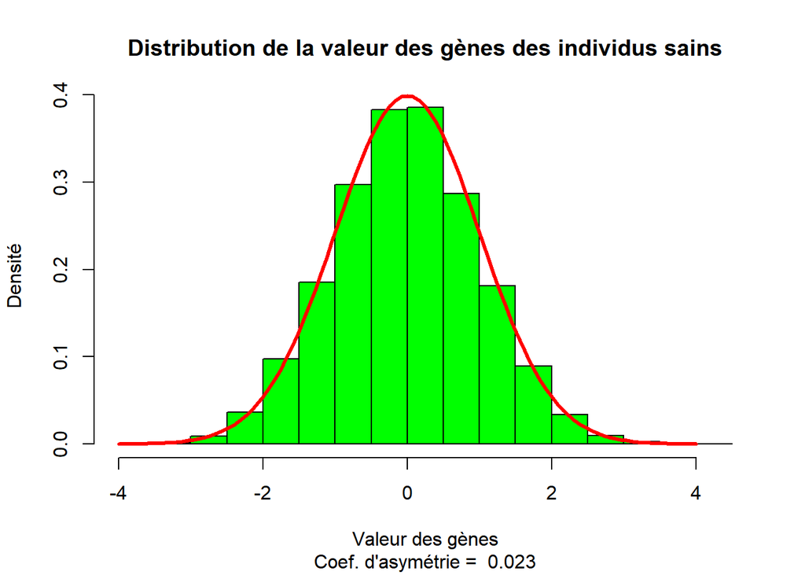

Nous pouvons supposer à première vue que que l’expression des gènes est distribuer selon une loi Gaussienne qui donne une bonne répartition de la distribution par rapport à la distribution des gènes des individus malades ci-dessous.

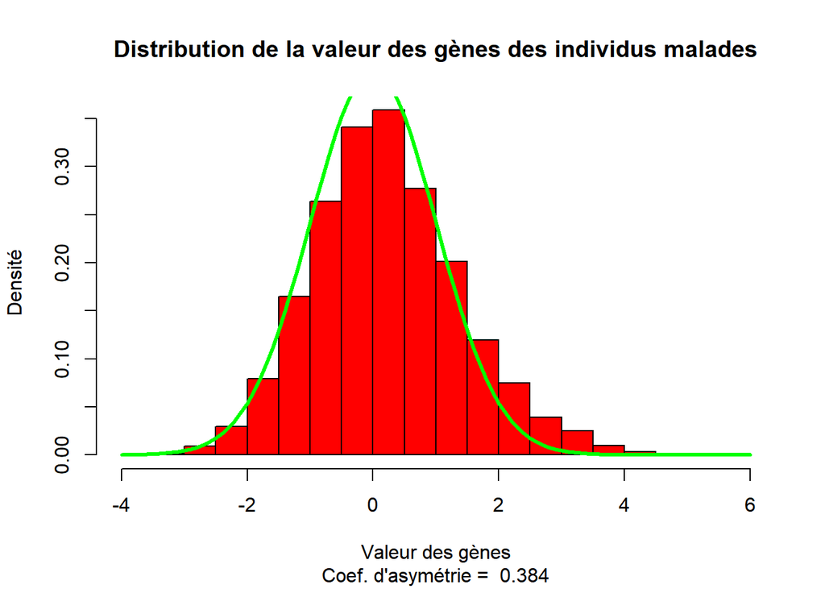

Nous remarquons alors que la distribution des gènes n’est pas la même lorqu’un individus est malade. C’est pour cela que nous pensons que les maladies peuvent être dues à la sous-expression ou sur-expression de certains gênes. L’ACP pourrait alors nous être utiles pour retrouver les gènes responsables, classer les individus et determiner si un nouvel individu est malade par l’analyse de ses gènes.

# 4 Analyse sous R

Afin de réaliser notre analyse, nous avons eu besoin de réaliser un programme sous le langage R. Le code source du programme vous est mis à disposition en annexe. Nous allons voir ensemble comment le faire fonctionner afin de poursuivre l’analyse de nos patients.

## 4.1 Présentation du programme

Nous avons souhaité écrire ce programme afin qu’il soit le plus général possible, réutilisable pour des cas différents. Nous avons essayé de réaliser des fonctions simples à utiliser, complet et graphiquement clair.  
D’autres bibliothèques sont capable de réaliser des ACP (ade4, FactoMineR, …), elles nous permettrons alors de verifier que nous résultats sont corrects et nous pouvons nous en inspirer pour restituer les resultats de nos fonctions.

## 4.2 Utilisation

Notre objectif est de rendre l’utilisation de notre programme le plus simple possible.  
Pour utiliser le programme, il faut suivre deux étapes :

### 4.2.1 Initialisation :

La première étape est l’initialisation. C’est le calcul de l’ACP à proprement parler. Elle fonctionne très simplement, en voici sa signature :

```
nantes_pca <- function(table, center=T, scale=T, numberOfAxis=NULL, additionalVariables=NULL, additionalIndividus=NULL)
```

On a donc un seul argument obligatoire, c’est la matrice des données brutes. Il est bien sûr possible de réaliser l’analyse en centrée-normée. Ensuite il est possible de choisir le nombre d’axes (ou composantes) à retenir pour l’analyse. Par défaut, le programme tentera de retrouver le nombre d’axes de manière automatique. Nous pouvons aussi ajouter qu’il est possible d’indiquer que certains individus et/ou certaines variables sont supplémentaires.

Au retour de cette fonction, on a une liste avec un maximum d’informations : coordonnées, contribution et qualité des variables/individus, éléments de la SVD (Singular Values Decomposition, ou Décomposition en Valeurs Singulières en français), soit les matrices U et V et les valeurs propres.

Grace à ce résultat, nous pouvons passer à la deuxième étape : la représentation.

### 4.2.2 Représentation :

Nous avons souhaité réunir tous les résultats que nous avons eu besoin lors des analyses étudiées en cours. Chaque représentation est réalisée par une fonction differente, mais elles sont toutes réunies dans cette fonction :

```
displayFullSummary <- function(pca, useOriginalTable = F, displayLimit = NULL, colors = NULL, beLike = NULL, numberOfClasses = 2)
```

Encore une fois, nous avons misé sur le simple. `pca` est le résutat de la première fonction, c’est encore une fois le seul argument obligatoire.  
Ensuite nous avons quelques moyens de personnaliser notre analyse : - `useOriginalTable` nous propose de réaliser une analyse univariée sur les données avant qu’elles soient transformées (centrées-réduites) ou non.  
- `displayLimit` est nous permet de réduire la taille de l’affichage lors de la présentation des coordonnées/contributions/qualités des variables et des individus.  
- `colors` colore le graphique des individus. Elle peut être utilisée afin de determiner le nombre de groupes lors de la classification (ex : si on colore les individus en rouge, bleu et noir, cela sera considéré comme 3 groupes). Il est aussi possible de lui donner la valeur “auto” pour que les couleurs se répartissent en fonction du nombre de classes définies par l’argument `numberOfClasses`.  
- `beLike` adapte les representations pour ressembler à d’autres bibliothèques. La représentation par défaut ressemble à celle d’ADE4, mais en passant “FactoMineR” en argument, nous réorientons les graphes pour être identique aux leurs.  
- `numberOfClasses` définit le nombre de groupes pour la classification.

Il suffit de lancer cette fonction pour voir apparaitre tous les resultats nécessaires à une bonne analyse en composantes principales.

## 4.3 Resultats

Voyons à quoi peut ressembler cette analyse avec un exemple : CSP.  
Lançons l’initialisation :

```r
table <- recuperer_donnees_en_matrice("csp.txt", entete = T)
pca <- nantes_pca(table)
```

Voyons à quoi peut ressembler les representations :

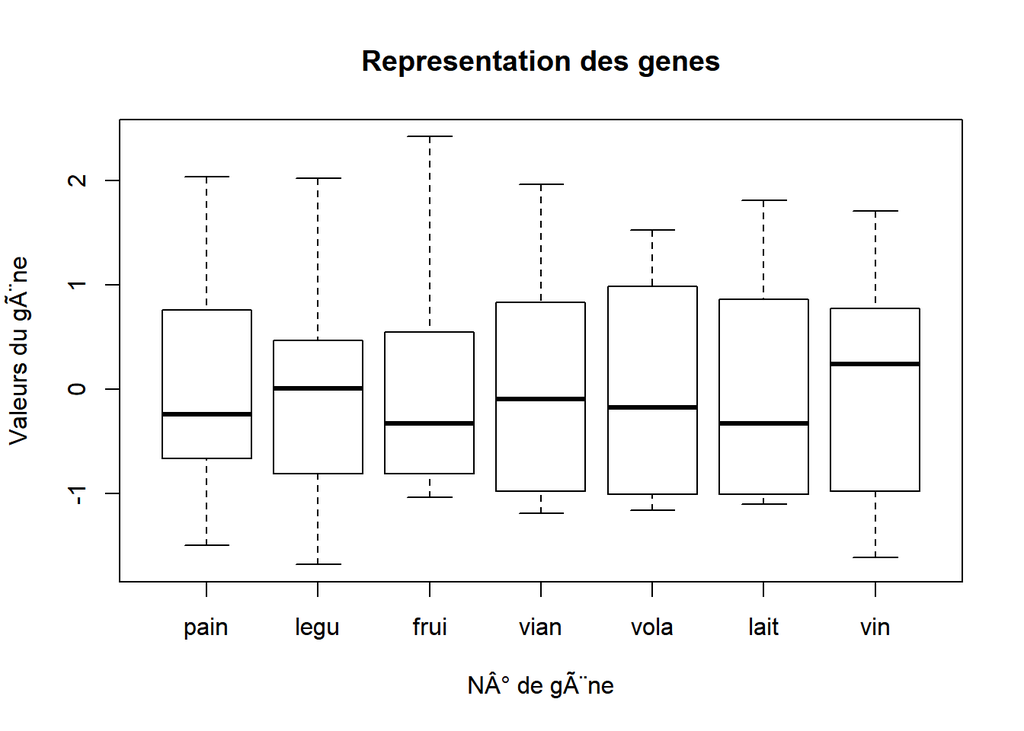

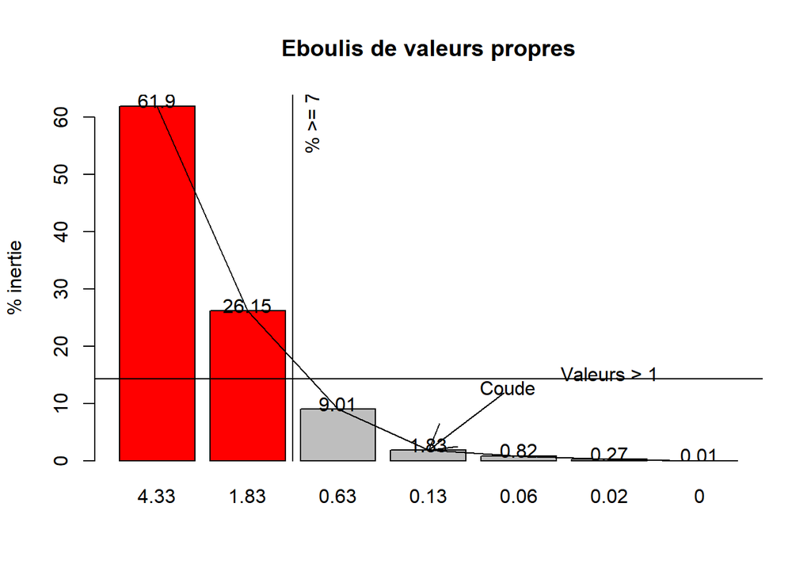

```
          [,1]       [,2]       [,3]       [,4]       [,5]        [,6]
pain 1.0000000  0.5931102  0.1961388  0.3212691  0.2480083 0.855574797
legu 0.5931102  1.0000000  0.8562502  0.8810807  0.8267774 0.662798738
frui 0.1961388  0.8562502  1.0000000  0.9594767  0.9255419 0.332188558
vian 0.3212691  0.8810807  0.9594767  1.0000000  0.9817853 0.374590641
vola 0.2480083  0.8267774  0.9255419  0.9817853  1.0000000 0.232891845
lait 0.8555748  0.6627987  0.3321886  0.3745906  0.2328918 1.000000000
vin  0.3037612 -0.3564682 -0.4862806 -0.4372353 -0.4001570 0.006879604
             [,7]
pain  0.303761226
legu -0.356468250
frui -0.486280578
vian -0.437235281
vola -0.400157002
lait  0.006879604
vin   1.000000000
```

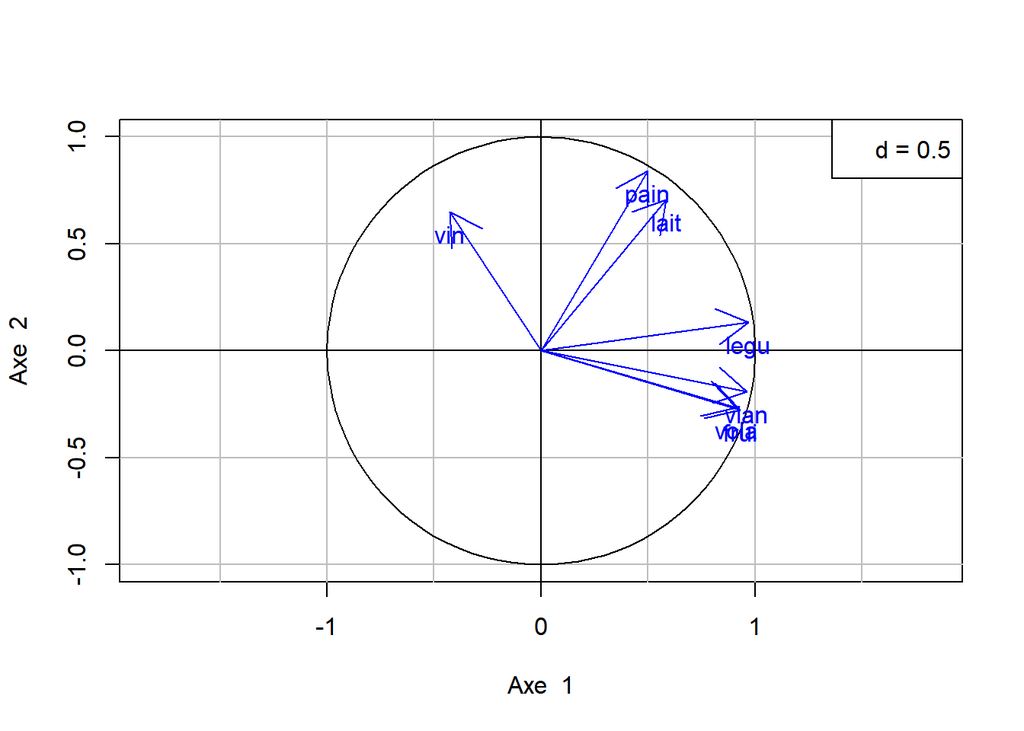

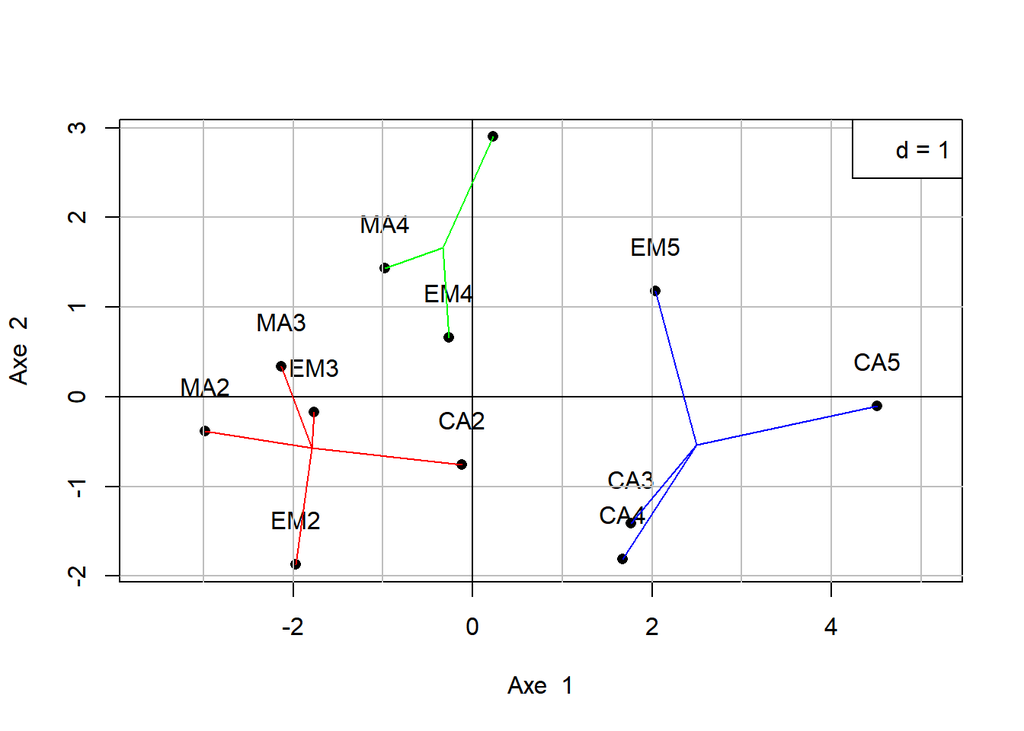

```
[1] "CoordonnÃ©es des individus"
    Axe 1 Axe 2
MA2 -2.99 -0.38
EM2 -1.97 -1.87
CA2 -0.12 -0.76
MA3 -2.13  0.34
EM3 -1.77 -0.17
CA3  1.77 -1.42
MA4 -0.97  1.43
EM4 -0.26  0.66
CA4  1.67 -1.81
MA5  0.23  2.90
EM5  2.04  1.18
CA5  4.51 -0.11
[1] "[CTR en %]"
     Axe 1  Axe 2
MA2 205.74   7.88
EM2  89.86 191.45
CA2   0.35  31.37
MA3 104.85   6.23
EM3  72.27   1.58
CA3  72.27 109.41
MA4  21.91 112.15
EM4   1.60  23.84
CA4  64.49 179.63
MA5   1.23 459.58
EM5  95.84  76.27
CA5 469.60   0.60
[1] "[QLT en %]"
   Axe 1 Axe 2
1  98.41  1.59
2  52.63 47.37
3   2.57 97.43
4  97.55  2.45
5  99.09  0.91
6  60.99 39.01
7  31.62 68.38
8  13.72 86.28
9  45.95 54.05
10  0.63 99.37
```

[output cut: 36 more lines]

```
frui 86.33  7.72
vian 92.56  3.65
vola 83.04  7.07
lait 34.15 49.97
vin  18.34 42.01
[1] "Variables contributant le plus Ã  l'axe 1 (positif)"
 legu  vian  frui  vola
21.70 21.36 19.92 19.16
[1] "Variables contributant le plus Ã  l'axe 1 (negatif)"
named numeric(0)
[1] "Variables contributant le plus Ã  l'axe 2 (positif)"
 pain  lait   vin
38.70 27.30 22.95
[1] "Variables contributant le plus Ã  l'axe 2 (negatif)"
named numeric(0)
```

```r
displayFullSummary(pca, colors = "auto", numberOfClasses = 3)
```

On a donc, par ordre chronologique :  
- Un graphique “global” qui represente toutes les variables sous forme de boite à moustache. (fonction `displayGlobal()`)  
- Un éboulis de valeurs propres, utilisé pour définir le nombre de composantes à sélectionner. (fonction `displayScreePlot()`)  
- Une matrice de corrélation des variables. Il est interressant de savoir que lorsqu’il y a de nombreuses variables, la matrice est représentée graphiquement, comme nous le verrons dans ce rapport lorsque nous analysons 1000 variables. (fonction `displayCorrelation()`)  
- Le cercle de corrélation afin de voir graphiquement la contribution des variables sur les composantes principales. (fonction `displayVariables()`)  
- Le graphique des individus qui représente la projection de chaque individus sur les composantes. (fonction `displayIndividus()`)  
- Le détail des coordonnées, contributions et qualité de représentation des variables et des individus selon chaque axes. On indique les plus grosses contributions sur chaque axe. (fonctions `displayInertieIndividus()` et `displayInertieVariables()`)

## 4.4 Comparaison avec l’existant

Il existe quelques autres bibliothèques permettant de réaliser des ACP. Nous avons ici vérifié nos résultats avec les bibliothèques ADE4 et FactoMineR. Nous avons essayé de comparer les valeurs retrouvées avec celles des autres bibliothèques, et ce par ces fonctions :

```
comparaisonAvecADE4(tabel, center = T, scale = T, ind.sup = NULL, var.sup = NULL, numberOfAxis = 5)
comparaisonAvecFactoMineR(tabel, center = T, scale = T, ind.sup = NULL, var.sup = NULL, numberOfAxis = 5)
```

Une serie de tests des differentes valeurs nous permet de savoir si tout est identique ou sinon les valeurs qui diffèrent sont affichées à l’écran. Par chance, nous n’avons jusque là aucune difference avec ces deux bibliothèques :

```r
comparaisonAvecADE4(table)
```

```
[1] "Comparaison avec ADE4 :"
[1] "-----------------------"
[1] "Valeurs propres :"
[1] "Dimensions identiques :  7  x  1"
[1] "Pas de difference"
[1] "CoordonnÃ©es des individus :"
[1] "Dimensions identiques :  12  x  5"
[1] "Pas de difference"
[1] "CoordonnÃ©es des variables :"
[1] "Dimensions identiques :  7  x  5"
[1] "Pas de difference"
[1] TRUE
[1] "Tout est identique! Bravo."
```

```
[1] TRUE
```

```r
comparaisonAvecFactoMineR(table)
```

```
[1] "Comparaison avec FactoMineR :"
[1] "-----------------------------"
[1] "Valeurs propres :"
[1] "Dimensions identiques :  7  x  1"
[1] "Pas de difference"
[1] "Matrice U :"
[1] "Dimensions identiques :  12  x  5"
[1] "Pas de difference"
[1] "Matrice V :"
[1] "Dimensions identiques :  7  x  5"
[1] "Pas de difference"
[1] "Valeurs singuliÃ¨res :"
[1] "Dimensions identiques :  7  x  1"
[1] "Pas de difference"
[1] "CoordonnÃ©es des individus :"
[1] "Dimensions identiques :  12  x  5"
[1] "Pas de difference"
[1] "CoordonnÃ©es des variables :"
[1] "Dimensions identiques :  7  x  5"
[1] "Pas de difference"
[1] TRUE
[1] "Tout est identique! Bravo."
```

```
[1] TRUE
```

## 4.5 Limites

Les limites actuelles de ces fonctions sont :  
- mauvaise gestion des valeurs `NA` - pas encore de gestion des colonnes qualitatives

Toutes ces limites ont comme futur d’être corrigées, mais au jour de notre rendu de rapport, elles sont présentes. Pour la suite de cette analyse, cela ne nous contraindra pas.

# 5 L’ACP

Nous avons commencé à faire une ACP sur notre toutes nos variables en même temps. Cependant, l’inertie de nos points se retrouvent au centre de notre cercle de corrélation et nos axes factorielles ne représentent pas bien la réalité de notre études.

Cela est précisé par le graphique des valeurs propres où seule la prmière valeur propre explique nos données de l’étude de avec la règle du coude. On remarque bien que pour avoir une représentation qui explique au moins 70% de l’inertie, il faudrait que nous gardions 24 dimensions, et que 39 dimensions ont une valeur propre supérieure à 1.

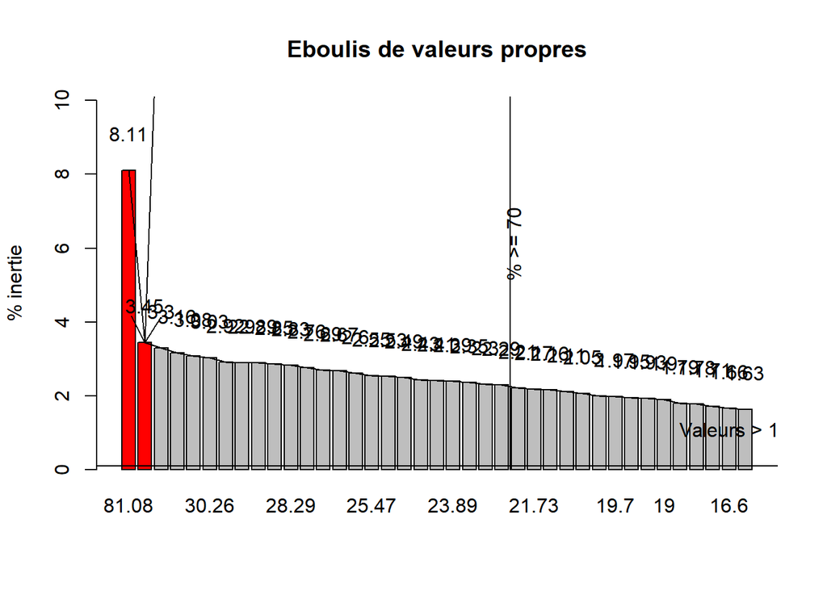

Au vu de notre étude, on ne devrait prend qu’un seul axe, puisque la deuxième valeur propre décroit fortement par rapport à la première (règle du coude). De plus, on recherche le génotype des individus malades, donc un seul axe expliquerait la corrélation de ce groupe de gènes.

Dans un soucis d’affichage dans nos graphiques, nous utiliserons 2 axes, bien que le second ne nous semble pas expliquer quoi que ce soit.

Ci-dessous, l’ACP effectuée sous R :

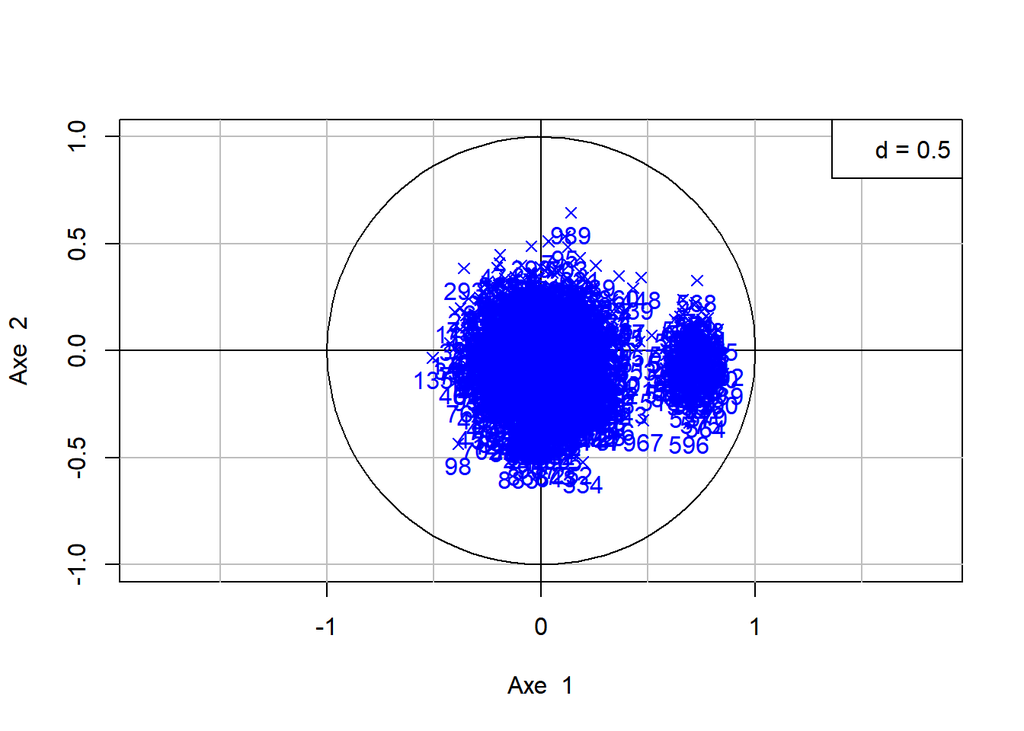

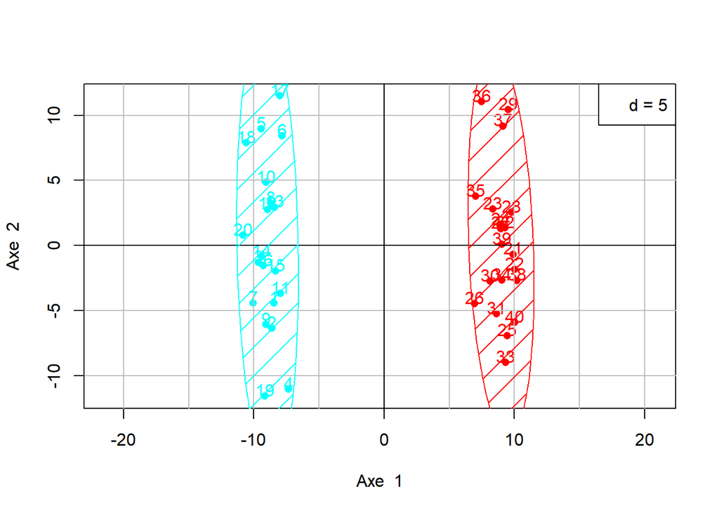

On remarque que les individus sont divisés 2 en groupes. On retrouve les sains à gauche de l’axe 1 et les individus malades à droite. De plus, sur le crecle de corrélation, on peut voir un groupe de gènes qui se démarquent vers la droite avec un cosinus supérieur à 0.5. On pense que c’est l’expression de ces gènes qui déterminent si un individu est malade ou sain.

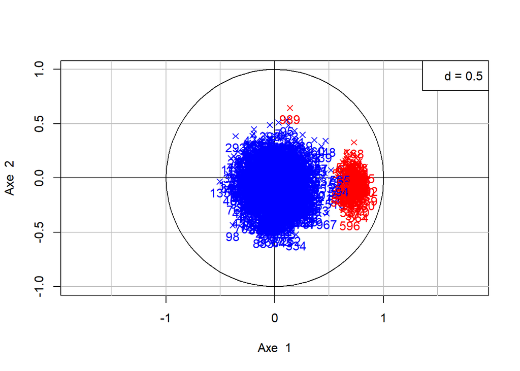

# 6 Analyse supplémentaire

Cependant, l’inertie de l’axe 1 est peu importante (8%) et on retrouve beaucoup de gènes vers le centre de l’ACP. Ces gènes ne résument donc pas l’information disponible : bien qu’on puisse penser que ces gènes déterminent si un individu est malade ou non, l’inertie de l’axe 1 est trop faible pour que cela soit une certitude. L’ACP contient trop de variables inutiles.

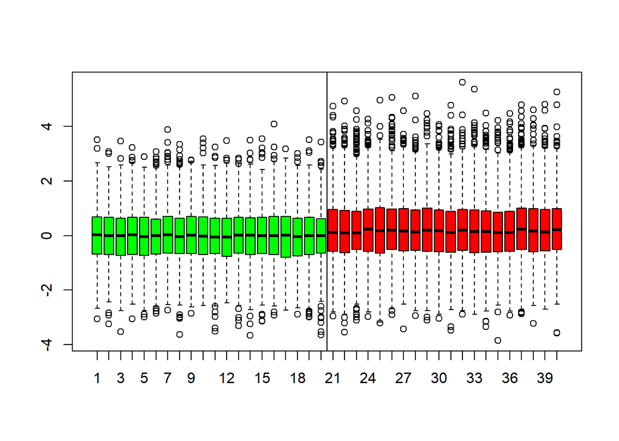

On s’interresse aux valeurs atypiques de ce graphique (c’est à dire les valeurs en dehors de la boite à moustache). Les patients malades ont beaucoups plus de gênes qui sont sur-exprimés par rapport aux individus saints Nous retrouvons donc ce resultat :

```r
variables_extremes <- apply(as.matrix(pca$var$coord[, 1]), 1, function(col){ min(abs(col)) > 0.5 })
table_extreme <- table[,variables_extremes]
print(paste("Nous considérons ", ncol(table_extreme), " variables 'extremes'", collapse=""))
```

```
[1] "Nous considérons  112  variables 'extremes'"
```

On va donc réaliser une ACP en ne considérant seulement ces variables-ci.

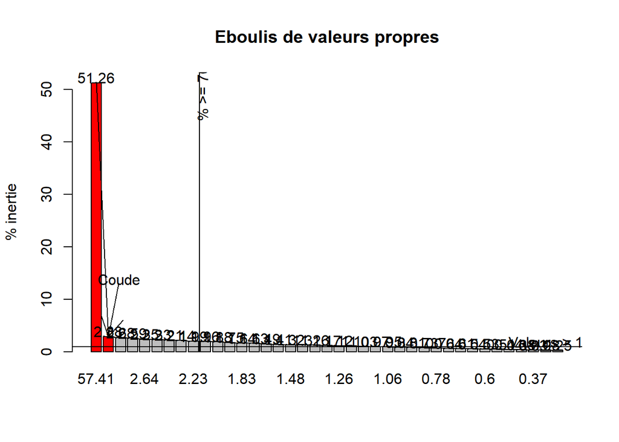

```r
pca_extreme <- nantes_pca(table_extreme, numberOfAxis = 2)
displayScreePlot(pca_extreme)
```

On voit que dans l’éboulis de valeurs propres, la deuxième valeur est beaucoup moins significative.

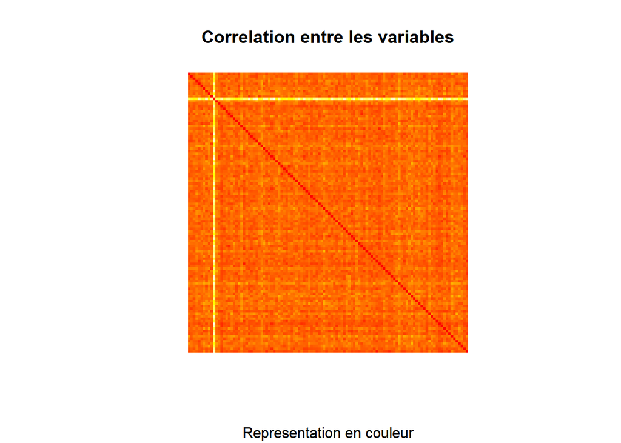

```r
displayCorrelation(pca_extreme)
```

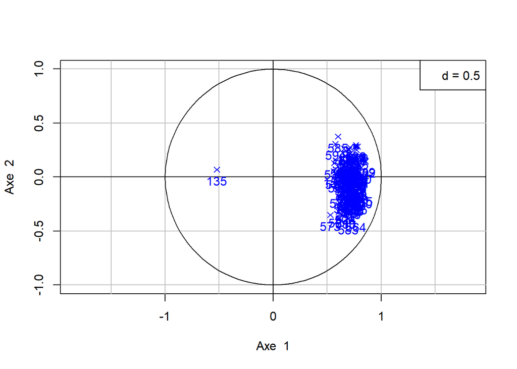

```r
displayVariables(pca_extreme, useArrows = F)
```

Nos conjectures semblent encore plus vraies, on a le même resultat que précédement mais cela se confirme car on peut voir une inertie sur cet axe qui augment jusqu’à 50%. En regardant la projection des individus sur les axes, on remarque que ces gènes determinent ces individus. On a bien retrouvé les gènes exprimés par les individus malades.

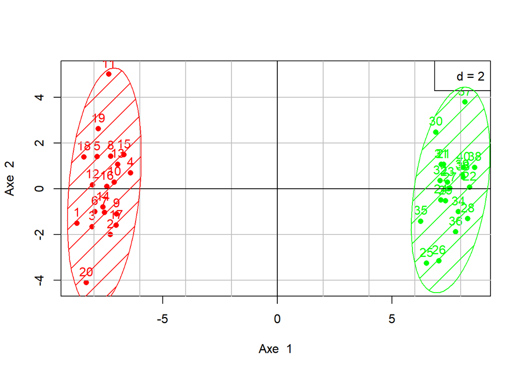

```r
displayClasses(pca_extreme, colors=c("green", "red"))
```

En appliquant une fonction de classification non-suppervisée par “k-means”, on peut bien voir que les deux groupes se distinguent.